# Views on climate change of Intro Bio students

Meghan Duffy

March 7, 2018

#What are the views of Introductory Biology students on climate change? And do those views change after taking Intro Bio?

Note: only analyzing data from students who took both the pre- and the post-surveys. Also only analyzing data for students who answered validation question correctly.

```r
library(tidyverse)
```

```r
library(cowplot)
library(likert)
library(BSDA)
ccdata <- read.csv("ccsurvey_F17_quantitative.csv", na.strings = "NA")
colnames(ccdata)
```

```
##  [1] "took_pre_CC"               "took_post_CC"
##  [3] "CC_ConsensusTemp_pre"      "CC_Important_pre"
##  [5] "CC_HarmPeople_pre"         "CC_ScientistsWhether_pre"
##  [7] "CC_Beliefs_pre"            "CC_Worried_pre"
##  [9] "CC_BeliefsFillIn_pre"      "CC_ChangeMind_pre"
## [11] "CC_Validation_pre"         "CC_HarmYou_pre"
## [13] "CC_ScientistsWhy_pre"      "CC_Happening_pre"
## [15] "CC_ConsensusCause_pre"     "CC_Thought_pre"
## [17] "CC_Friends_pre"            "CC_View_pre"
## [19] "CC_HarmPeople_post"        "CC_Thought_post"
## [21] "CC_Beliefs_post"           "CC_Worried_post"
## [23] "CC_ConsensusCause_post"    "CC_View_post"
## [25] "CC_ScientistsWhether_post" "CC_BeliefsFillIn_post"
## [27] "CC_ChangeMind_post"        "CC_ConsensusTemp_post"
## [29] "CC_Validation_post"        "CC_Important_post"
## [31] "CC_Friends_post"           "CC_ChangedMe_post"
## [33] "CC_HarmYou_post"           "CC_Happening_post"
## [35] "CC_ScientistsWhy_post"
```

```r
cctookboth <- subset(ccdata, took_pre_CC == 1 & took_post_CC == 1)
cctookboth <- subset(cctookboth, CC_Validation_pre == "SomewhatAgree" & CC_Validation_post == "SomewhatAgree")
```

Yikes! 49 of the 169 people who took both surveys didn’t answer the validation question correctly on both surveys. That leaves us with 120 students.

```r
ccdataw18 <- read.csv("ccsurvey_WN18_quantitative.csv")
colnames(ccdataw18)
```

```
##  [1] "took_pre_CC"                   "took_post_CC"
##  [3] "CCPre_ScientistsWhy_pre"       "CCPre_ScientistsWhether_pre"
##  [5] "CCPre_Happening_pre"           "CCPre_Causes_pre"
##  [7] "CCPre_Worried_pre"             "CCPre_ConsensusCause_pre"
##  [9] "CCPre_Thought_pre"             "CCPost_Worried_post"
## [11] "CCPost_ScientistsWhy_post"     "CCPost_Validation_post"
## [13] "CCPost_ScientistsWhether_post" "CCPost_Thought_post"
## [15] "CCPost_Causes_post"            "CCPost_ConsensusCause_post"
## [17] "CCPost_Happening_post"         "CCPost_ChangedMe_post"
```

```r
cctookbothw18 <- subset(ccdataw18, took_pre_CC == 1 & took_post_CC == 1)
cctookbothw18 <- subset(cctookbothw18, CCPost_Validation_post == "SomewhatAgree")
```

### Combined data set

```r
cctookbothtocombineF17 <- cctookboth[c("CC_Happening_pre","CC_Happening_post","CC_Worried_pre","CC_Worried_post","CC_ScientistsWhether_pre","CC_ScientistsWhether_post","CC_ScientistsWhy_pre","CC_ScientistsWhy_post","CC_ConsensusCause_pre","CC_ConsensusCause_post","CC_Thought_pre","CC_Thought_post","CC_ChangedMe_post")]
cctookbothtocombineW18 <- cctookbothw18[c("CCPre_Happening_pre","CCPost_Happening_post","CCPre_Worried_pre","CCPost_Worried_post","CCPre_ScientistsWhether_pre","CCPost_ScientistsWhether_post","CCPre_ScientistsWhy_pre","CCPost_ScientistsWhy_post","CCPre_ConsensusCause_pre","CCPost_ConsensusCause_post","CCPre_Thought_pre","CCPost_Thought_post","CCPost_ChangedMe_post")]

cctookbothtocombineW18 <- dplyr::rename(cctookbothtocombineW18, CC_Happening_pre=CCPre_Happening_pre, CC_Happening_post=CCPost_Happening_post,CC_Worried_pre=CCPre_Worried_pre,CC_Worried_post=CCPost_Worried_post,CC_ScientistsWhether_pre=CCPre_ScientistsWhether_pre,CC_ScientistsWhether_post=CCPost_ScientistsWhether_post,CC_ScientistsWhy_pre=CCPre_ScientistsWhy_pre,CC_ScientistsWhy_post=CCPost_ScientistsWhy_post,CC_ConsensusCause_pre=CCPre_ConsensusCause_pre,CC_ConsensusCause_post=CCPost_ConsensusCause_post,CC_Thought_pre=CCPre_Thought_pre,CC_Thought_post=CCPost_Thought_post,CC_ChangedMe_post=CCPost_ChangedMe_post)

cctookbothtocombineF17$Semester <- "F17"
cctookbothtocombineW18$Semester <- "W18"

cctookbothcombined <- bind_rows(cctookbothtocombineF17,cctookbothtocombineW18)
```

# Do the students think climate change is happening?

Students were asked: Do you think that climate change is happening? Options: - Yes, and I’m extremely sure - Yes, and I’m very sure - Yes, and I’m somewhat sure - Yes, but I’m not at all sure - No, and I’m extremely sure - No, and I’m very sure - No, and I’m somewhat sure - No, but I’m not at all sure - I don’t know

```r
CCHappeningPrecombined <- cctookbothcombined$CC_Happening_pre
CCHappeningPrecombined <- as.data.frame(CCHappeningPrecombined)
names(CCHappeningPrecombined)[1] = c("Answer")

CCHappeningPostcombined <- cctookbothcombined$CC_Happening_post
CCHappeningPostcombined <- as.data.frame(CCHappeningPostcombined)
names(CCHappeningPostcombined)[1] = c("Answer")

CCHappeningPrecombined$prepost <- rep("pre",nrow(CCHappeningPrecombined))
CCHappeningPostcombined$prepost <- rep("post",nrow(CCHappeningPostcombined))

CCHappeningDataBindcombined <- bind_rows(CCHappeningPrecombined,CCHappeningPostcombined)
CCHappeningDataBindcombined$Answer <- factor(CCHappeningDataBindcombined$Answer,
                                            c("YesExtrSure",
                                              "YesVerySure",
                                              "YesSomeSure",
                                              "YesNotSure",
                                              "DK",
                                              "NoSomeSure"))

CCHappeningDataBindcombined$prepost <- factor(CCHappeningDataBindcombined$prepost,
                                            c("pre",
                                              "post"))
```

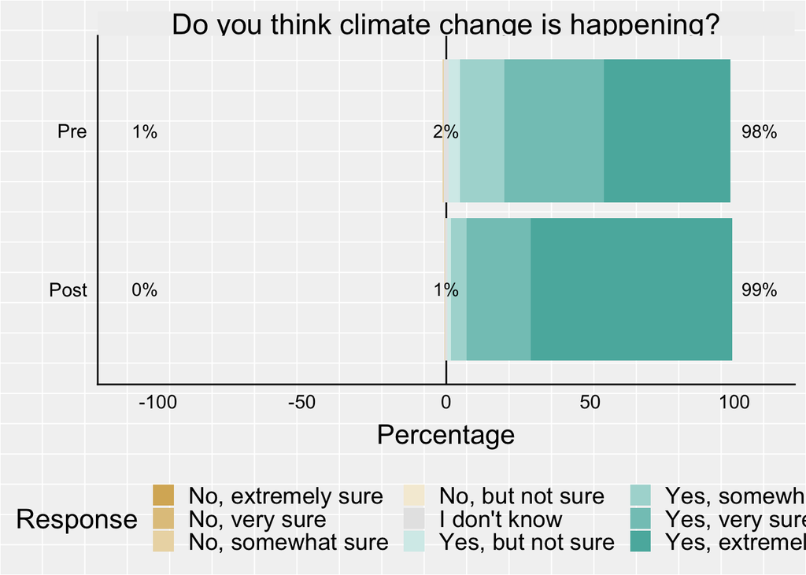

```r
cchappeningresponsescombined <- CCHappeningDataBindcombined %>%
  select(Answer)

CCHappeningDataBindcombined$prepost <- plyr::mapvalues(CCHappeningDataBindcombined$prepost , from = c("pre", "post"), to = c("Pre","Post"))

CCHappeningDataBindcombined$prepost <- factor(CCHappeningDataBindcombined$prepost, c("Post","Pre"))

# rename the responses and order the data
cchappeningresponsescombined$Answer <- plyr::mapvalues(cchappeningresponsescombined$Answer, from = c("YesExtrSure",
                                              "YesVerySure",
                                              "YesSomeSure",
                                              "YesNotSure",
                                              "DK",
                                              "NoSomeSure"),
                                              to = c("Yes, extremely sure",
                                                     "Yes, very sure",
                                                     "Yes, somewhat sure",
                                                     "Yes, but not sure",
                                                     "I don't know",
                                                     "No, somewhat sure"))


cchappeningresponsescombined$Answer <- factor(cchappeningresponsescombined$Answer,
                                 c("No, extremely sure",
                                   "No, very sure",
                                   "No, somewhat sure",
                                    "No, but not sure",
                                    "I don't know",
                                    "Yes, but not sure",
                                    "Yes, somewhat sure",
                                    "Yes, very sure",
                                    "Yes, extremely sure"))

cchappeningresponsescombined_grouping <- CCHappeningDataBindcombined %>%
  select(prepost)



counts = CCHappeningDataBindcombined %>%
  count(prepost) %>%
  mutate(variable=NA)

colnames(cchappeningresponsescombined)[1] <- "Do you think climate change is happening?"
likert_cchappeningcombined <- likert(cchappeningresponsescombined, grouping = cchappeningresponsescombined_grouping$prepost)

library(scales)
cchappeninglikertplotcombined = plot(likert_cchappeningcombined,legend.position="bottom",text.size=4) +
  scale_y_continuous(limits=c(-100,150)) +
  coord_flip(ylim=c(-110,110)) +
  theme(text = element_text(size=17), strip.text.x = element_text(size = 18)) +
  guides(fill = guide_legend(nrow=3))
cchappeninglikertplotcombined <- ggplot_gtable(ggplot_build(cchappeninglikertplotcombined))
cchappeninglikertplotcombined$layout$clip <- "off"
cchappeninglikertplotcombined.mpg <- plot(cchappeninglikertplotcombined)
```

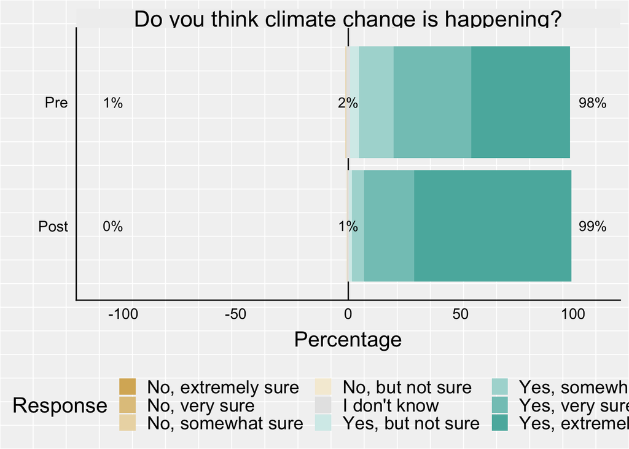

```r
plot(cchappeninglikertplotcombined)
```

```r
save_plot("cchappeninglikertplotcombined.jpg", cchappeninglikertplotcombined, base_width = 8, base_height = 5)
```

```r
CChappeningsummarycombined <- CCHappeningDataBindcombined %>%
  filter(Answer != "") %>%
  group_by(prepost,Answer) %>%
  summarise(n=n()) %>%
  mutate(rel.freq = round(100 * n/sum(n), 0))

CChappeningsummarycombined
```

```
## # A tibble: 12 x 4
## # Groups:   prepost [2]
##    prepost Answer          n rel.freq
##    <fct>   <fct>       <int>    <dbl>
##  1 Post    YesExtrSure   266       70
##  2 Post    YesVerySure    85       22
##  3 Post    YesSomeSure    20        5
##  4 Post    YesNotSure      5        1
##  5 Post    DK              3        1
##  6 Post    NoSomeSure      1        0
##  7 Pre     YesExtrSure   164       44
##  8 Pre     YesVerySure   130       35
##  9 Pre     YesSomeSure    57       15
## 10 Pre     YesNotSure     15        4
## 11 Pre     DK              6        2
## 12 Pre     NoSomeSure      2        1
```

```r
extrhappening <- prop.test(x = c(164, 266), n = c(372, 372))
extrhappening
```

```
##
##  2-sample test for equality of proportions with continuity
##  correction
##
## data:  c(164, 266) out of c(372, 372)
## X-squared = 56.211, df = 1, p-value = 6.511e-14
## alternative hypothesis: two.sided
## 95 percent confidence interval:
##  -0.3450693 -0.2033177
## sample estimates:
##    prop 1    prop 2
## 0.4408602 0.7150538
```

# Who do students think is causing climate change?

```r
CCBeliefsPre <- cctookboth$CC_Beliefs_pre
CCBeliefsPre <- as.data.frame(CCBeliefsPre)
names(CCBeliefsPre)[1] = c("Answer")

CCBeliefsPost <- cctookboth$CC_Beliefs_post
CCBeliefsPost <- as.data.frame(CCBeliefsPost)
names(CCBeliefsPost)[1] = c("Answer")

CCBeliefsPre$prepost <- rep("pre",nrow(CCBeliefsPre))
CCBeliefsPost$prepost <- rep("post",nrow(CCBeliefsPost))

CCBeliefsDataBind <- bind_rows(CCBeliefsPre,CCBeliefsPost)
CCBeliefsDataBind$prepost <- factor(CCBeliefsDataBind$prepost,
                                            c("pre",
                                              "post"))
```

Summary: The percentage of students who identified humans as the primary cause of climate change increased from 69% on the pre-survey to 91% on the post-survey.

```r
CCBeliefsDataBindAll <- CCBeliefsDataBind

CCBeliefsDataBindAll$Answer <- plyr::mapvalues(CCBeliefsDataBindAll$Answer , from = c("Both", "Humans", "Natural", "Other", "ExtentUnknown","NotHappening"), to = c("Equally humans and natural","Mostly humans", "Mostly natural", "Other", "Contributions unknown or unknowable", "Climate change is not happening"))

CCBeliefsDataBindAll$prepost <- plyr::mapvalues(CCBeliefsDataBindAll$prepost , from = c("pre", "post"), to = c("Pre","Post"))

CCbeliefssummaryall <- CCBeliefsDataBindAll %>%
  filter(Answer != "") %>%
  group_by(prepost,Answer) %>%
  summarise(n=n()) %>%
  mutate(rel.freq = round(100 * n/sum(n), digits=1))

CCbeliefssummaryall
```

```
## # A tibble: 11 x 4
## # Groups:   prepost [2]
##    prepost Answer                                  n rel.freq
##    <fct>   <chr>                               <int>    <dbl>
##  1 Pre     Climate change is not happening         2      1.7
##  2 Pre     Contributions unknown or unknowable     2      1.7
##  3 Pre     Equally humans and natural             26     21.7
##  4 Pre     Mostly humans                          83     69.2
##  5 Pre     Mostly natural                          1      0.8
##  6 Pre     Other                                   6      5
##  7 Post    Climate change is not happening         1      0.8
##  8 Post    Contributions unknown or unknowable     2      1.7
##  9 Post    Equally humans and natural              6      5
## 10 Post    Mostly humans                         109     91.6
## 11 Post    Other                                   1      0.8
```

```r
samplesizes <- CCBeliefsDataBindAll %>%
  filter(Answer != "") %>%
  group_by(prepost) %>%
  summarise(n=n())

samplesizes
```

```
## # A tibble: 2 x 2
##   prepost     n
##   <fct>   <int>
## 1 Pre       120
## 2 Post      119
```

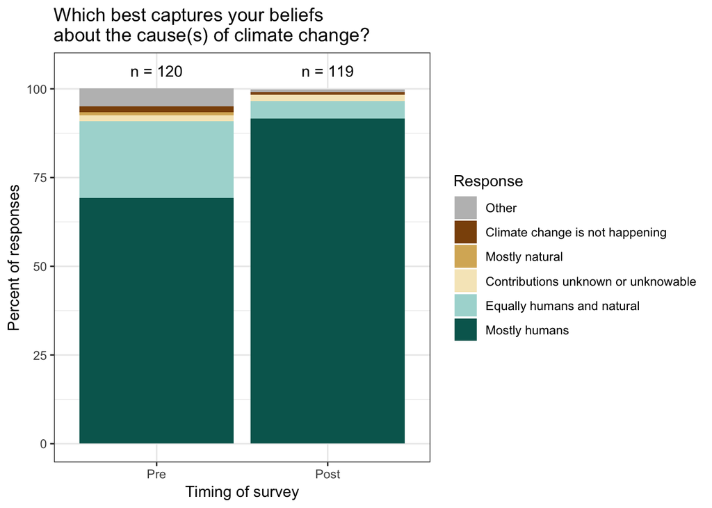

```r
# order the responses
CCbeliefssummaryall$Answer <- factor(CCbeliefssummaryall$Answer,
                                 c("Other",
                                   "Climate change is not happening",
                                   "Mostly natural",
                                   "Contributions unknown or unknowable",
                                   "Equally humans and natural",
                                   "Mostly humans"))


CCBeliefsDataBindAll$prepost <- factor(CCBeliefsDataBindAll$prepost,
                                       c("Pre","Post"))

ccbeliefsstackedbarplot <- ggplot(CCbeliefssummaryall, aes(y=rel.freq, x=prepost)) +
    geom_col(aes(fill=Answer)) +
  ylab("Percent of responses") +
  xlab("Timing of survey") +
  scale_fill_manual(values=c("gray","#8c510a","#d8b365","#f6e8c3","#ABD9D5","#01665e")) +
  ggtitle("Which best captures your beliefs \nabout the cause(s) of climate change?") +
  guides(fill=guide_legend(title="Response"))  +
  ylim(0,105) +
  annotate("text", x = 1, y = 105, label = paste("n = 120")) +
  annotate("text", x = 2, y = 105, label = paste("n = 119")) +
  theme_bw()


  ccbeliefsstackedbarplot
```

```r
save_plot("ccbeliefsstackedbarplot.jpg", ccbeliefsstackedbarplot, base_width = 6.5, base_height = 5)
```

```r
mostlyhumans <- prop.test(x = c(83, 109), n = c(120, 119))
mostlyhumans
```

```
##
##  2-sample test for equality of proportions with continuity
##  correction
##
## data:  c(83, 109) out of c(120, 119)
## X-squared = 17.634, df = 1, p-value = 2.677e-05
## alternative hypothesis: two.sided
## 95 percent confidence interval:
##  -0.3291656 -0.1194338
## sample estimates:
##    prop 1    prop 2
## 0.6916667 0.9159664
```

```r
equally <- prop.test(x = c(26, 6), n = c(120, 119))
equally
```

```
##
##  2-sample test for equality of proportions with continuity
##  correction
##
## data:  c(26, 6) out of c(120, 119)
## X-squared = 12.843, df = 1, p-value = 0.0003388
## alternative hypothesis: two.sided
## 95 percent confidence interval:
##  0.07433935 0.25815365
## sample estimates:
##     prop 1     prop 2
## 0.21666667 0.05042017
```

## The scientific consensus is that climate change is caused mostly by humans activities. Do students agree?

CC_ConsensusCause The scientific consensus is that climate change is o Caused mostly by human activities o Caused mostly by natural changes in the environment o Caused equally by both human activities and natural changes in the environment o Other o Not happening o I don’t know what the scientific consensus is o There is no scientific consensus

```r
CCConsensusCausePrecombined <- cctookbothcombined$CC_ConsensusCause_pre
CCConsensusCausePrecombined <- as.data.frame(CCConsensusCausePrecombined)
names(CCConsensusCausePrecombined)[1] = c("Answer")

CCConsensusCausePostcombined <- cctookbothcombined$CC_ConsensusCause_post
CCConsensusCausePostcombined <- as.data.frame(CCConsensusCausePostcombined)
names(CCConsensusCausePostcombined)[1] = c("Answer")

CCConsensusCausePrecombined$prepost <- rep("pre",nrow(CCConsensusCausePrecombined))
CCConsensusCausePostcombined$prepost <- rep("post",nrow(CCConsensusCausePostcombined))

CCConsensusCauseDataBindcombined <- bind_rows(CCConsensusCausePrecombined,CCConsensusCausePostcombined)
CCConsensusCauseDataBindcombined$prepost <- factor(CCConsensusCauseDataBindcombined$prepost,
                                            c("pre",
                                              "post"))
```

```r
CCconsensuscausesummarycombined <- CCConsensusCauseDataBindcombined %>%
  filter(Answer != "") %>%
  group_by(prepost,Answer) %>%
  summarise(n=n()) %>%
  mutate(rel.freq = round(100 * n/sum(n), 0))

CCconsensuscausesummarycombined
```

```
## # A tibble: 12 x 4
## # Groups:   prepost [2]
##    prepost Answer           n rel.freq
##    <fct>   <chr>        <int>    <dbl>
##  1 pre     Both            70       19
##  2 pre     DK              58       16
##  3 pre     Humans         230       62
##  4 pre     Natural          5        1
##  5 pre     NoConsensus      5        1
##  6 pre     NotHappening     2        1
##  7 pre     Other            2        1
##  8 post    Both            45       12
##  9 post    DK              24        6
## 10 post    Humans         299       78
## 11 post    Natural         11        3
## 12 post    NoConsensus      4        1
```

```r
samplesizes <- CCConsensusCauseDataBindcombined %>%
  filter(Answer != "") %>%
  group_by(prepost) %>%
  summarise(n=n())

samplesizes
```

```
## # A tibble: 2 x 2
##   prepost     n
##   <fct>   <int>
## 1 pre       372
## 2 post      383
```

```r
mostlyhumans <- prop.test(x = c(230, 299), n = c(372, 383))
mostlyhumans
```

```
##
##  2-sample test for equality of proportions with continuity
##  correction
##
## data:  c(230, 299) out of c(372, 383)
## X-squared = 22.962, df = 1, p-value = 1.653e-06
## alternative hypothesis: two.sided
## 95 percent confidence interval:
##  -0.22950406 -0.09529451
## sample estimates:
##    prop 1    prop 2
## 0.6182796 0.7806789
```

```r
equally <- prop.test(x = c(70, 45), n = c(372, 383))
equally
```

```
##
##  2-sample test for equality of proportions with continuity
##  correction
##
## data:  c(70, 45) out of c(372, 383)
## X-squared = 6.7639, df = 1, p-value = 0.009302
## alternative hypothesis: two.sided
## 95 percent confidence interval:
##  0.01686749 0.12448965
## sample estimates:
##    prop 1    prop 2
## 0.1881720 0.1174935
```

```r
CCConsensusCauseDataBindAllcombined <- CCConsensusCauseDataBindcombined %>%
    filter(Answer != "")

CCConsensusCauseDataBindAllcombined$Answer <- plyr::mapvalues(CCConsensusCauseDataBindAllcombined$Answer , from = c("Both", "Humans", "Natural", "Other", "DK","NoConsensus"), to = c("Equally humans and natural","Mostly humans", "Mostly natural", "Other", "I don't know", "There is no scientific consensus"))


CCConsensusCauseDataBindAllcombined$prepost <- plyr::mapvalues(CCConsensusCauseDataBindAllcombined$prepost , from = c("pre", "post"), to = c("Pre","Post"))

CCconsensuscausesummaryallcombined <- CCConsensusCauseDataBindAllcombined %>%
  filter(Answer != "") %>%
  group_by(prepost,Answer) %>%
  summarise(n=n()) %>%
  mutate(rel.freq = round(100 * n/sum(n), digits=1))

CCconsensuscausesummaryallcombined
```

```
## # A tibble: 12 x 4
## # Groups:   prepost [2]
##    prepost Answer                               n rel.freq
##    <fct>   <chr>                            <int>    <dbl>
##  1 Pre     Equally humans and natural          70     18.8
##  2 Pre     I don't know                        58     15.6
##  3 Pre     Mostly humans                      230     61.8
##  4 Pre     Mostly natural                       5      1.3
##  5 Pre     NotHappening                         2      0.5
##  6 Pre     Other                                2      0.5
##  7 Pre     There is no scientific consensus     5      1.3
##  8 Post    Equally humans and natural          45     11.7
##  9 Post    I don't know                        24      6.3
## 10 Post    Mostly humans                      299     78.1
## 11 Post    Mostly natural                      11      2.9
## 12 Post    There is no scientific consensus     4      1
```

```r
samplesizes <- CCConsensusCauseDataBindAllcombined %>%
  filter(Answer != "") %>%
  group_by(prepost) %>%
  summarise(n=n())

samplesizes
```

```
## # A tibble: 2 x 2
##   prepost     n
##   <fct>   <int>
## 1 Pre       372
## 2 Post      383
```

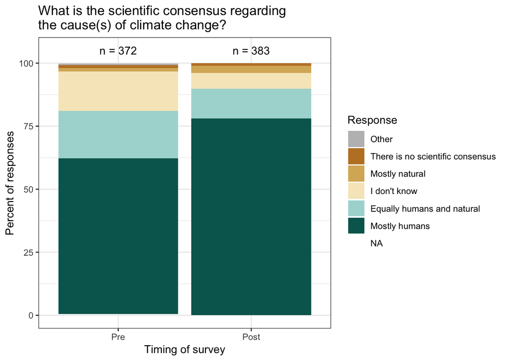

```r
# order the responses
CCconsensuscausesummaryallcombined$Answer <- factor(CCconsensuscausesummaryallcombined$Answer,
                                 c("Other",
                                   "There is no scientific consensus",
                                   "Mostly natural",
                                   "I don't know",
                                   "Equally humans and natural",
                                   "Mostly humans"))

ccconsensuscausestackedbarplotcombined <- ggplot(CCconsensuscausesummaryallcombined, aes(y=rel.freq, x=prepost)) +
    geom_col(aes(fill=Answer)) +
  ylab("Percent of responses") +
  xlab("Timing of survey") +
  scale_fill_manual(values=c("gray","#bf812d","#d8b365","#f6e8c3","#ABD9D5","#01665e")) +
  ggtitle("What is the scientific consensus regarding \nthe cause(s) of climate change?") +
  guides(fill=guide_legend(title="Response")) +
  ylim(0,105) +
  annotate("text", x = 1, y = 105, label = paste("n = 372")) +
  annotate("text", x = 2, y = 105, label = paste("n = 383")) +
  theme_bw()

ccconsensuscausestackedbarplotcombined
```

```r
save_plot("ccconsensuscausestackedbarplotcombined.jpg", ccconsensuscausestackedbarplotcombined, base_width = 6.5, base_height = 5)
```

## Scientists have a good understanding of whether climate change is occurring

### Views on scientific consensus about whether climate change is happening

```r
CCScientistsWhetherPrecombined <- cctookbothcombined$CC_ScientistsWhether_pre
CCScientistsWhetherPrecombined <- as.data.frame(CCScientistsWhetherPrecombined)
names(CCScientistsWhetherPrecombined)[1] = c("Answer")

CCScientistsWhetherPostcombined <- cctookbothcombined$CC_ScientistsWhether_post
CCScientistsWhetherPostcombined <- as.data.frame(CCScientistsWhetherPostcombined)
names(CCScientistsWhetherPostcombined)[1] = c("Answer")

CCScientistsWhetherPrecombined$prepost <- rep("pre",nrow(CCScientistsWhetherPrecombined))
CCScientistsWhetherPostcombined$prepost <- rep("post",nrow(CCScientistsWhetherPostcombined))

CCScientistsWhetherDataBindcombined <- bind_rows(CCScientistsWhetherPrecombined,CCScientistsWhetherPostcombined)

CCScientistsWhetherDataBindcombined$Answer <- factor(CCScientistsWhetherDataBindcombined$Answer,
                                            c("StronglyAgree",
                                              "SomewhatAgree",
                                              "Neither",
                                              "SomewhatDisagree",
                                              "StronglyDisagree",
                                              "DK"))

CCScientistsWhetherDataBindcombined$prepost <- factor(CCScientistsWhetherDataBindcombined$prepost,
                                            c("pre",
                                              "post"))
```

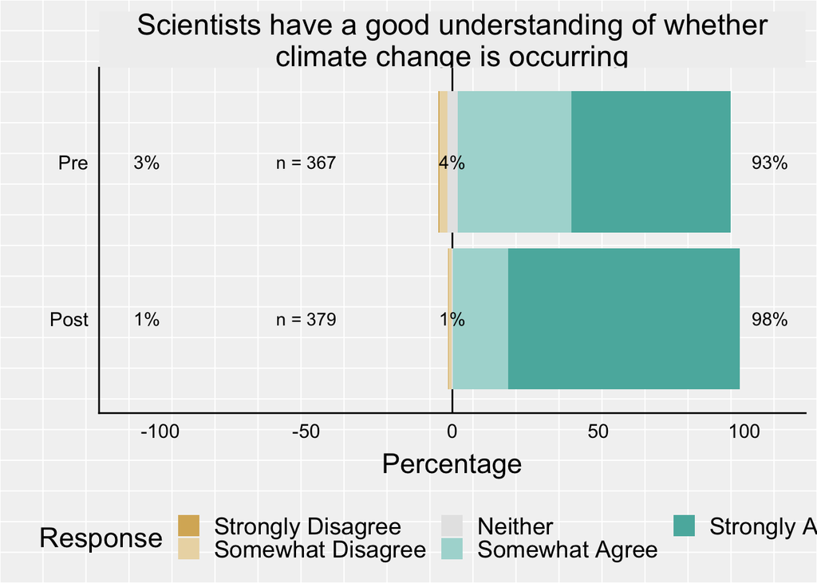

```r
CCScientistsWhetherDataBindcombined <- CCScientistsWhetherDataBindcombined %>%
  filter(Answer != "")

CCScientistsWhetherDataBindNoDKcombined <- CCScientistsWhetherDataBindcombined %>%
  filter(Answer != "DK")

ccscientistswhetherresponsescombined <- CCScientistsWhetherDataBindNoDKcombined %>%
  select(Answer)

CCScientistsWhetherDataBindNoDKcombined$prepost <- plyr::mapvalues(CCScientistsWhetherDataBindNoDKcombined$prepost , from = c("pre", "post"), to = c("Pre","Post"))

CCScientistsWhetherDataBindNoDKcombined$prepost <- factor(CCScientistsWhetherDataBindNoDKcombined$prepost, c("Post","Pre"))

# rename and order the responses

ccscientistswhetherresponsescombined$Answer <- plyr::mapvalues(ccscientistswhetherresponsescombined$Answer, from = c("StronglyAgree",
                                              "SomewhatAgree",
                                              "Neither",
                                              "SomewhatDisagree",
                                              "StronglyDisagree"),
                                   to = c("Strongly Agree",
                                              "Somewhat Agree",
                                              "Neither",
                                              "Somewhat Disagree",
                                              "Strongly Disagree"))

ccscientistswhetherresponsescombined$Answer <- factor(ccscientistswhetherresponsescombined$Answer,
                                 c("Strongly Disagree",
                                   "Somewhat Disagree",
                                    "Neither",
                                    "Somewhat Agree",
                                    "Strongly Agree"))

ccscientistswhetherresponsescombined_grouping <- CCScientistsWhetherDataBindNoDKcombined %>%
  select(prepost)

counts = CCScientistsWhetherDataBindNoDKcombined %>%
  count(prepost) %>%
  mutate(variable=NA)

colnames(ccscientistswhetherresponsescombined)[1] <- "Scientists have a good understanding of whether climate change is occurring"
likert_ccscientistswhethercombined <- likert(ccscientistswhetherresponsescombined, grouping = ccscientistswhetherresponsescombined_grouping$prepost)


ccscientistswhetherlikertplotcombined = plot(likert_ccscientistswhethercombined,legend.position="bottom",text.size=4) +
  scale_y_continuous(limits=c(-100,150)) +
  coord_flip(ylim=c(-110,110)) +
  theme(text = element_text(size=17), strip.text.x = element_text(size = 18)) +
  annotate("text", x = 2, y = -50, label = paste("n = 367")) +
  annotate("text", x = 1, y = -50, label = paste("n = 379")) +
  guides(fill = guide_legend(nrow=2))
ccscientistswhetherlikertplotcombined <- ggplot_gtable(ggplot_build(ccscientistswhetherlikertplotcombined))
ccscientistswhetherlikertplotcombined$layout$clip <- "off"
ccscientistswhetherlikertplotcombined.mpg <- plot(ccscientistswhetherlikertplotcombined)
```

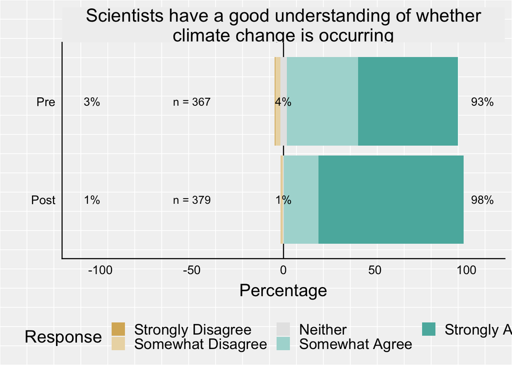

```r
plot(ccscientistswhetherlikertplotcombined)
```

```r
save_plot("ccscientistswhetherlikertplotcombined.jpg", ccscientistswhetherlikertplotcombined, base_width = 12, base_height = 5)

CCScientistsWhetherDataBindDKcombined <- CCScientistsWhetherDataBindcombined %>%
  filter(Answer == "DK")


CCScientistsWhetherDataBindcombinedsummary <- CCScientistsWhetherDataBindcombined %>%
  group_by(prepost, Answer) %>%
  summarise(n=n()) %>%
  mutate(rel.freq = round(100 * n/sum(n), 0))

CCScientistsWhetherDataBindcombinedsummary
```

```
## # A tibble: 12 x 4
## # Groups:   prepost [2]
##    prepost Answer               n rel.freq
##    <fct>   <fct>            <int>    <dbl>
##  1 pre     StronglyAgree      200       54
##  2 pre     SomewhatAgree      143       38
##  3 pre     Neither             13        3
##  4 pre     SomewhatDisagree    10        3
##  5 pre     StronglyDisagree     1        0
##  6 pre     DK                   5        1
##  7 post    StronglyAgree      303       79
##  8 post    SomewhatAgree       72       19
##  9 post    Neither              2        1
## 10 post    SomewhatDisagree     4        1
## 11 post    StronglyDisagree     1        0
## 12 post    DK                   1        0
```

```r
samplesizes <- CCScientistsWhetherDataBindcombined %>%
  group_by(prepost) %>%
  summarise(n=n())

samplesizes
```

```
## # A tibble: 2 x 2
##   prepost     n
##   <fct>   <int>
## 1 pre       372
## 2 post      383
```

```r
stronglyagree <- prop.test(x = c(200, 303), n = c(372, 383))
stronglyagree
```

```
##
##  2-sample test for equality of proportions with continuity
##  correction
##
## data:  c(200, 303) out of c(372, 383)
## X-squared = 53.396, df = 1, p-value = 2.726e-13
## alternative hypothesis: two.sided
## 95 percent confidence interval:
##  -0.3211334 -0.1858432
## sample estimates:
##    prop 1    prop 2
## 0.5376344 0.7911227
```

## Views on scientific consensus on why climate change is happening

```r
CCScientistsWhyPrecombined <- cctookbothcombined$CC_ScientistsWhy_pre
CCScientistsWhyPrecombined <- as.data.frame(CCScientistsWhyPrecombined)
names(CCScientistsWhyPrecombined)[1] = c("Answer")

CCScientistsWhyPostcombined <- cctookbothcombined$CC_ScientistsWhy_post
CCScientistsWhyPostcombined <- as.data.frame(CCScientistsWhyPostcombined)
names(CCScientistsWhyPostcombined)[1] = c("Answer")

CCScientistsWhyPrecombined$prepost <- rep("pre",nrow(CCScientistsWhyPrecombined))
CCScientistsWhyPostcombined$prepost <- rep("post",nrow(CCScientistsWhyPostcombined))

CCScientistsWhyDataBindcombined <- bind_rows(CCScientistsWhyPrecombined,CCScientistsWhyPostcombined)

CCScientistsWhyDataBindcombined$Answer <- factor(CCScientistsWhyDataBindcombined$Answer,
                                            c("StronglyAgree",
                                              "SomewhatAgree",
                                              "Neither",
                                              "SomewhatDisagree",
                                              "StronglyDisagree",
                                              "DK"))

CCScientistsWhyDataBindcombined$prepost <- factor(CCScientistsWhyDataBindcombined$prepost,
                                            c("pre",
                                              "post"))
```

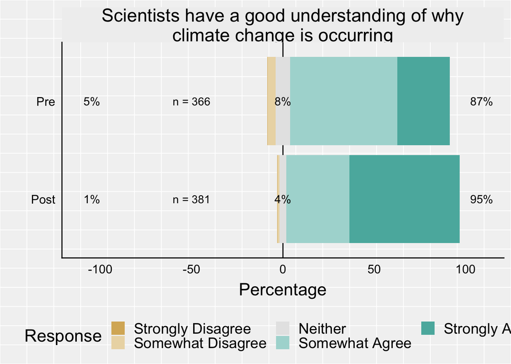

```r
CCScientistsWhyDataBindcombined <- CCScientistsWhyDataBindcombined  %>%
  filter(Answer != "")

CCScientistsWhyDataBindNoDKcombined <- CCScientistsWhyDataBindcombined %>%
  filter(Answer != "DK")

ccscientistswhyresponsescombined <- CCScientistsWhyDataBindNoDKcombined %>%
  select(Answer)

CCScientistsWhyDataBindNoDKcombined$prepost <- plyr::mapvalues(CCScientistsWhyDataBindNoDKcombined$prepost , from = c("pre", "post"), to = c("Pre","Post"))

CCScientistsWhyDataBindNoDKcombined$prepost <- factor(CCScientistsWhyDataBindNoDKcombined$prepost, c("Post","Pre"))

# rename and order the responses

ccscientistswhyresponsescombined$Answer <- plyr::mapvalues(ccscientistswhyresponsescombined$Answer, from = c("StronglyAgree",
                                              "SomewhatAgree",
                                              "Neither",
                                              "SomewhatDisagree",
                                              "StronglyDisagree"),
                                   to = c("Strongly Agree",
                                              "Somewhat Agree",
                                              "Neither",
                                              "Somewhat Disagree",
                                              "Strongly Disagree"))

ccscientistswhyresponsescombined$Answer <- factor(ccscientistswhyresponsescombined$Answer,
                                 c("Strongly Disagree",
                                   "Somewhat Disagree",
                                    "Neither",
                                    "Somewhat Agree",
                                    "Strongly Agree"))

ccscientistswhyresponsescombined_grouping <- CCScientistsWhyDataBindNoDKcombined %>%
  select(prepost)

counts = CCScientistsWhyDataBindNoDKcombined %>%
  count(prepost) %>%
  mutate(variable=NA)

colnames(ccscientistswhyresponsescombined)[1] <- "Scientists have a good understanding of why climate change is occurring"
likert_ccscientistswhycombined <- likert(ccscientistswhyresponsescombined, grouping = ccscientistswhyresponsescombined_grouping$prepost)


ccscientistswhylikertplotcombined = plot(likert_ccscientistswhycombined,legend.position="bottom",text.size=4) +
  scale_y_continuous(limits=c(-100,150)) +
  coord_flip(ylim=c(-110,110)) +
  theme(text = element_text(size=17), strip.text.x = element_text(size = 18)) +
  guides(fill = guide_legend(nrow=2)) +
  annotate("text", x = 2, y = -50, label = paste("n = 366")) +
  annotate("text", x = 1, y = -50, label = paste("n = 381"))
ccscientistswhylikertplotcombined <- ggplot_gtable(ggplot_build(ccscientistswhylikertplotcombined))
ccscientistswhylikertplotcombined$layout$clip <- "off"
ccscientistswhylikertplotcombined.mpg <- plot(ccscientistswhylikertplotcombined)
```

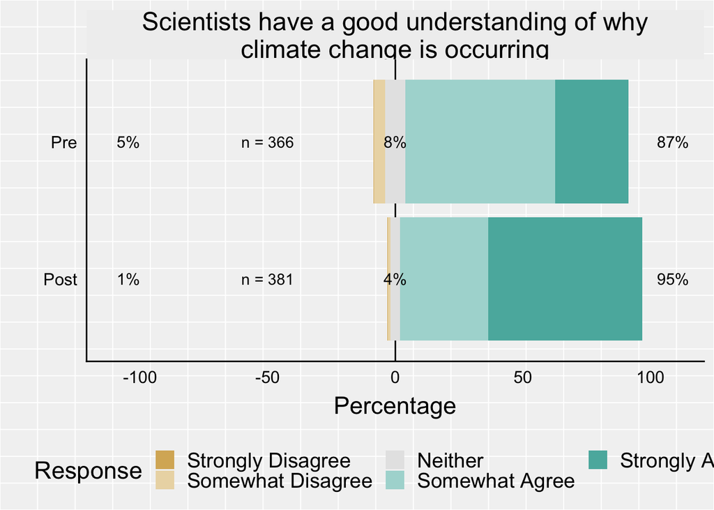

```r
plot(ccscientistswhylikertplotcombined)
```

```r
save_plot("ccscientistswhylikertplotcombined.jpg", ccscientistswhylikertplotcombined, base_width = 12, base_height = 5)

CCScientistsWhyDataBindDKcombined <- CCScientistsWhyDataBindcombined %>%
  filter(Answer == "DK")

CCScientistsWhyDataBindcombinedsummary <- CCScientistsWhyDataBindcombined %>%
  group_by(prepost, Answer) %>%
  summarise(n=n()) %>%
  mutate(rel.freq = round(100 * n/sum(n), 0))

CCScientistsWhyDataBindcombinedsummary
```

```
## # A tibble: 12 x 4
## # Groups:   prepost [2]
##    prepost Answer               n rel.freq
##    <fct>   <fct>            <int>    <dbl>
##  1 pre     StronglyAgree      105       28
##  2 pre     SomewhatAgree      215       58
##  3 pre     Neither             29        8
##  4 pre     SomewhatDisagree    16        4
##  5 pre     StronglyDisagree     1        0
##  6 pre     DK                   6        2
##  7 post    StronglyAgree      230       60
##  8 post    SomewhatAgree      132       34
##  9 post    Neither             14        4
## 10 post    SomewhatDisagree     4        1
## 11 post    StronglyDisagree     1        0
## 12 post    DK                   2        1
```

```r
samplesizes <- CCScientistsWhyDataBindcombined %>%
  group_by(prepost) %>%
  summarise(n=n())

samplesizes
```

```
## # A tibble: 2 x 2
##   prepost     n
##   <fct>   <int>
## 1 pre       372
## 2 post      383
```

```r
stronglyagree <- prop.test(x = c(105, 230), n = c(372, 383))
stronglyagree
```

```
##
##  2-sample test for equality of proportions with continuity
##  correction
##
## data:  c(105, 230) out of c(372, 383)
## X-squared = 76.157, df = 1, p-value < 2.2e-16
## alternative hypothesis: two.sided
## 95 percent confidence interval:
##  -0.3879820 -0.2485462
## sample estimates:
##    prop 1    prop 2
## 0.2822581 0.6005222
```

### Combined plot for whether & why combined data

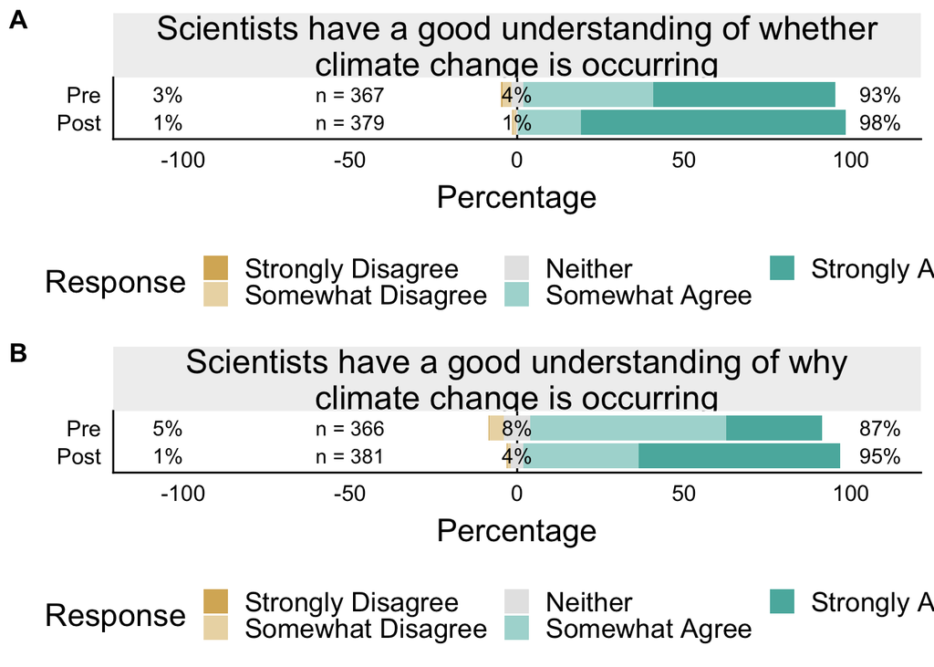

```r
combinedccwhetherwhyplotcombined <- plot_grid(ccscientistswhetherlikertplotcombined, ccscientistswhylikertplotcombined, labels=c('A', 'B'), nrow=2, ncol=1)
combinedccwhetherwhyplotcombined
```

```r
save_plot("combinedccwhetherwhyplotcombined.jpg", combinedccwhetherwhyplotcombined, base_width = 8, base_height = 8)
```

## What are student views on whether there’s a consensus that temperatures have increased in the past century?

CC_ConsensusTemp There is a strong scientific consensus that Earth’s temperature has increased in the past century. o Strongly agree o Somewhat agree o Neither agree nor disagree o Somewhat disagree o Strongly disagree o I don’t know

```r
CCConsensusTempPre <- cctookboth$CC_ConsensusTemp_pre
CCConsensusTempPre <- as.data.frame(CCConsensusTempPre)
names(CCConsensusTempPre)[1] = c("Answer")

CCConsensusTempPost <- cctookboth$CC_ConsensusTemp_post
CCConsensusTempPost <- as.data.frame(CCConsensusTempPost)
names(CCConsensusTempPost)[1] = c("Answer")

CCConsensusTempPre$prepost <- rep("pre",nrow(CCConsensusTempPre))
CCConsensusTempPost$prepost <- rep("post",nrow(CCConsensusTempPost))

CCConsensusTempDataBind <- bind_rows(CCConsensusTempPre,CCConsensusTempPost)

CCConsensusTempDataBind$Answer <- factor(CCConsensusTempDataBind$Answer,
                                            c("StronglyAgree",
                                              "SomewhatAgree",
                                              "Neither",
                                              "SomewhatDisagree",
                                              "StronglyDisagree",
                                              "DK"))

CCConsensusTempDataBind$prepost <- factor(CCConsensusTempDataBind$prepost,
                                            c("pre",
                                              "post"))
```

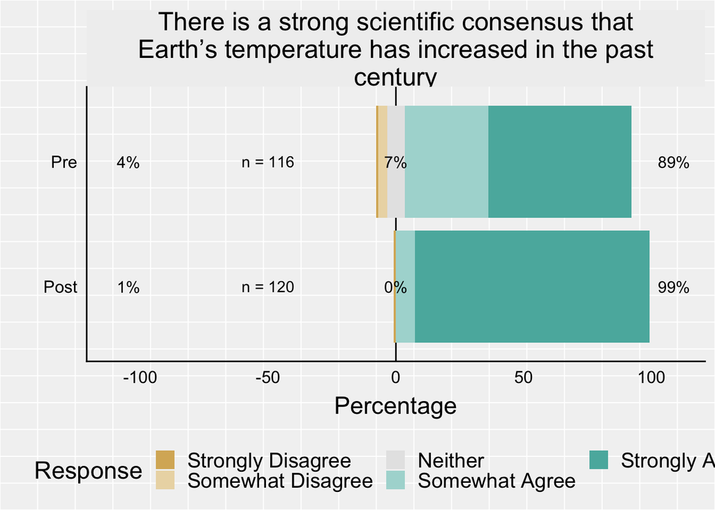

```r
CCConsensusTempDataBind <- CCConsensusTempDataBind  %>%
  filter(Answer != "")

CCConsensusTempDataBindNoDK <- CCConsensusTempDataBind %>%
  filter(Answer != "DK")

ccconsensustempresponses <- CCConsensusTempDataBindNoDK %>%
  select(Answer)

CCConsensusTempDataBindNoDK$prepost <- plyr::mapvalues(CCConsensusTempDataBindNoDK$prepost , from = c("pre", "post"), to = c("Pre","Post"))

CCConsensusTempDataBindNoDK$prepost <- factor(CCConsensusTempDataBindNoDK$prepost, c("Post","Pre"))

# rename and order the responses

ccconsensustempresponses$Answer <- plyr::mapvalues(ccconsensustempresponses$Answer, from = c("StronglyAgree",
                                              "SomewhatAgree",
                                              "Neither",
                                              "SomewhatDisagree",
                                              "StronglyDisagree"),
                                   to = c("Strongly Agree",
                                              "Somewhat Agree",
                                              "Neither",
                                              "Somewhat Disagree",
                                              "Strongly Disagree"))

ccconsensustempresponses$Answer <- factor(ccconsensustempresponses$Answer,
                                 c("Strongly Disagree",
                                   "Somewhat Disagree",
                                    "Neither",
                                    "Somewhat Agree",
                                    "Strongly Agree"))

ccconsensustempresponses_grouping <- CCConsensusTempDataBindNoDK %>%
  select(prepost)

counts = CCConsensusTempDataBindNoDK %>%
  count(prepost) %>%
  mutate(variable=NA)

colnames(ccconsensustempresponses)[1] <- "There is a strong scientific consensus that Earth’s temperature has increased in the past century"
likert_ccconsensustemp <- likert(ccconsensustempresponses, grouping = ccconsensustempresponses_grouping$prepost)

ccconsensustemplikertplot = plot(likert_ccconsensustemp,legend.position="bottom",text.size=4) +
  scale_y_continuous(limits=c(-100,150)) +
  coord_flip(ylim=c(-110,110)) +
  theme(text = element_text(size=17), strip.text.x = element_text(size = 18)) +
  annotate("text", x = 2, y = -50, label = paste("n = 116")) +
  annotate("text", x = 1, y = -50, label = paste("n = 120")) +
  guides(fill = guide_legend(nrow=2))
ccconsensustemplikertplot <- ggplot_gtable(ggplot_build(ccconsensustemplikertplot))
ccconsensustemplikertplot$layout$clip <- "off"
ccscientistswhylikertplot.mpg <- plot(ccconsensustemplikertplot)
```

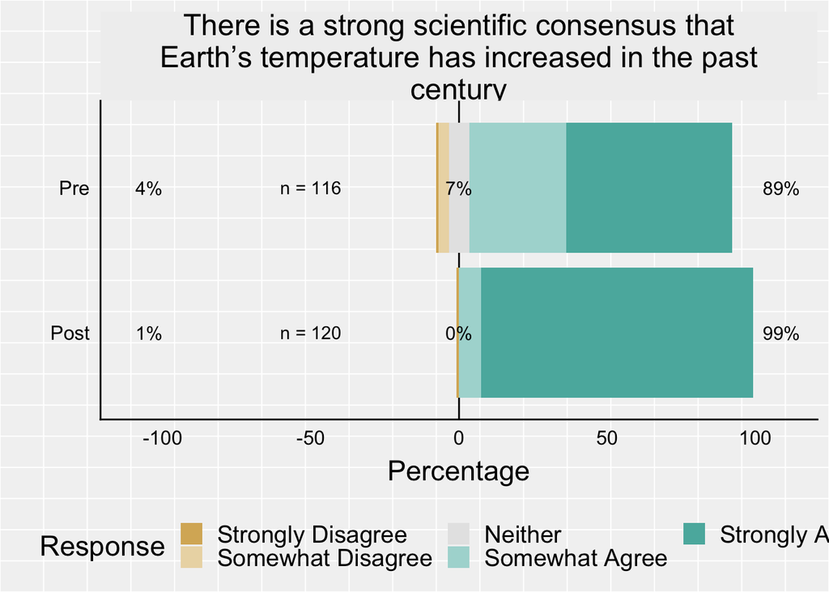

```r
plot(ccconsensustemplikertplot)
```

```r
save_plot("ccconsensustemplikertplot.jpg", ccconsensustemplikertplot, base_width = 8, base_height = 5)

CCConsensusTempDataBindDK <- CCConsensusTempDataBind %>%
  filter(Answer == "DK")

CCconsensustempsummary <- CCConsensusTempDataBind %>%
  filter(Answer != "") %>%
  group_by(prepost,Answer) %>%
  summarise(n=n()) %>%
  mutate(rel.freq = round(100 * n/sum(n), 0))

CCconsensustempsummary
```

```
## # A tibble: 9 x 4
## # Groups:   prepost [2]
##   prepost Answer               n rel.freq
##   <fct>   <fct>            <int>    <dbl>
## 1 pre     StronglyAgree       65       54
## 2 pre     SomewhatAgree       38       32
## 3 pre     Neither              8        7
## 4 pre     SomewhatDisagree     4        3
## 5 pre     StronglyDisagree     1        1
## 6 pre     DK                   4        3
## 7 post    StronglyAgree      110       92
## 8 post    SomewhatAgree        9        8
## 9 post    StronglyDisagree     1        1
```

```r
samplesizes <- CCConsensusTempDataBind %>%
  filter(Answer != "") %>%
  group_by(prepost) %>%
  summarise(n=n())

samplesizes
```

```
## # A tibble: 2 x 2
##   prepost     n
##   <fct>   <int>
## 1 pre       120
## 2 post      120
```

## When do students think climate change will start to harm people?

```r
CCHarmPeoplePre <- cctookboth$CC_HarmPeople_pre
CCHarmPeoplePre <- as.data.frame(CCHarmPeoplePre)
names(CCHarmPeoplePre)[1] = c("Answer")

CCHarmPeoplePost <- cctookboth$CC_HarmPeople_post
CCHarmPeoplePost <- as.data.frame(CCHarmPeoplePost)
names(CCHarmPeoplePost)[1] = c("Answer")

CCHarmPeoplePre$prepost <- rep("pre",nrow(CCHarmPeoplePre))
CCHarmPeoplePost$prepost <- rep("post",nrow(CCHarmPeoplePost))

CCHarmPeopleDataBind <- bind_rows(CCHarmPeoplePre,CCHarmPeoplePost)

CCHarmPeopleDataBind$Answer <- factor(CCHarmPeopleDataBind$Answer,
                                            c("Now",
                                              "Years10",
                                              "Years11to25",
                                              "Years26to50",
                                              "Years51to100",
                                              "After100",
                                              "NotHappening",
                                              "Never"))

CCHarmPeopleDataBind$prepost <- factor(CCHarmPeopleDataBind$prepost,
                                            c("pre",
                                              "post"))
```

Only 32% of students thought that climate change is harming people now on the pre-survey, whereas 62% of students chose that on the post-survey.

```r
CCHarmPeopleDataBind$prepost <- plyr::mapvalues(CCHarmPeopleDataBind$prepost , from = c("pre", "post"), to = c("Pre","Post"))

CCharmpeoplesummary <- CCHarmPeopleDataBind %>%
  subset(Answer != "") %>%
  group_by(prepost,Answer) %>%
  summarise(n=n()) %>%
  mutate(rel.freq = round(100 * n/sum(n), digits=1))

CCharmpeoplesummary
```

```
## # A tibble: 14 x 4
## # Groups:   prepost [2]
##    prepost Answer           n rel.freq
##    <fct>   <fct>        <int>    <dbl>
##  1 Pre     Now             39     32.5
##  2 Pre     Years10         11      9.2
##  3 Pre     Years11to25     22     18.3
##  4 Pre     Years26to50     18     15
##  5 Pre     Years51to100    15     12.5
##  6 Pre     After100        13     10.8
##  7 Pre     NotHappening     2      1.7
##  8 Post    Now             74     62.2
##  9 Post    Years10         14     11.8
## 10 Post    Years11to25     12     10.1
## 11 Post    Years26to50      7      5.9
## 12 Post    Years51to100     9      7.6
## 13 Post    After100         2      1.7
## 14 Post    NotHappening     1      0.8
```

```r
ntoplot <- CCHarmPeopleDataBind %>%
  subset(Answer != "") %>%
  group_by(prepost) %>%
  summarise(n=n())

ntoplot
```

```
## # A tibble: 2 x 2
##   prepost     n
##   <fct>   <int>
## 1 Pre       120
## 2 Post      119
```

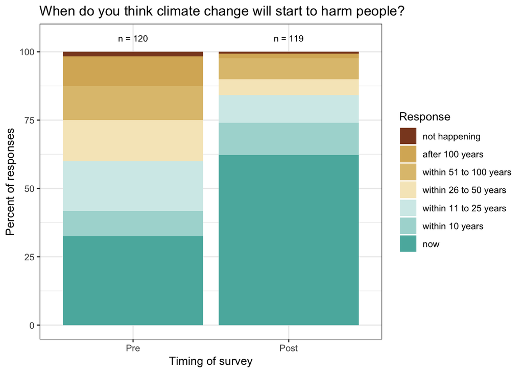

```r
CCharmpeoplesummary$Answer <- plyr::mapvalues(CCharmpeoplesummary$Answer ,
                                              from = c("Now","Years10", "Years11to25","Years26to50","Years51to100","After100","NotHappening"),
                                              to = c("now","within 10 years","within 11 to 25 years","within 26 to 50 years","within 51 to 100 years","after 100 years", "not happening"))

CCharmpeoplesummary$Answer <- factor(CCharmpeoplesummary$Answer,
                                     c("not happening",
                                       "after 100 years",
                                     "within 51 to 100 years",
                                     "within 26 to 50 years",
                                     "within 11 to 25 years",
                                     "within 10 years",
                                     "now"))

CCHarmPeoplePrePostPlotv2 <- ggplot(CCharmpeoplesummary) +
  geom_bar(aes(y=rel.freq, x=prepost, fill=Answer),stat='identity') +
  scale_fill_manual(values=c("sienna4","#D8B365", "#dfc27d", "#f6e8c3", "#D3EBE9","#ABD9D5", "#5AB4AC")) +
  theme(axis.title.y=element_blank()) +
  annotate("text",x=1,y=105,label="n = 120",size=3) +
  annotate("text",x=2,y=105,label="n = 119",size=3) +
  labs(y="Percent of responses",x = "Timing of survey") +
  labs(fill="Response") +
  ggtitle("When do you think climate change will start to harm people?")  +
    theme(plot.title = element_text(size = 16, face = "plain")) +
    theme(legend.position="bottom") +
  theme_bw()

CCHarmPeoplePrePostPlotv2
```

```r
save_plot("CCHarmPeoplePrePostPlotv2.jpg", CCHarmPeoplePrePostPlotv2, base_width = 6.5, base_height = 5)
```

```r
now <- prop.test(x = c(39, 74), n = c(120, 119))
now
```

```
##
##  2-sample test for equality of proportions with continuity
##  correction
##
## data:  c(39, 74) out of c(120, 119)
## X-squared = 19.948, df = 1, p-value = 7.956e-06
## alternative hypothesis: two.sided
## 95 percent confidence interval:
##  -0.4261041 -0.1675934
## sample estimates:
##    prop 1    prop 2
## 0.3250000 0.6218487
```

## How much do students think climate change will harm them?

Question & answer options: How much do you think climate change will harm you personally? o Not at all, because climate change is not happening o Not at all, even though climate change is happening o Only a little o A moderate amount o A great deal o I don’t know

The codes for those in the data are: - NotHappening - Somewhat {which doesn’t make sense given the answer text, but Kyle confirmed this on December 4 2018} - Little - Moderate - GreatDeal - DK

```r
CCHarmYouPre <- cctookboth$CC_HarmYou_pre
CCHarmYouPre <- as.data.frame(CCHarmYouPre)
names(CCHarmYouPre)[1] = c("Answer")

CCHarmYouPost <- cctookboth$CC_HarmYou_post
CCHarmYouPost <- as.data.frame(CCHarmYouPost)
names(CCHarmYouPost)[1] = c("Answer")

CCHarmYouPre$prepost <- rep("pre",nrow(CCHarmYouPre))
CCHarmYouPost$prepost <- rep("post",nrow(CCHarmYouPost))

CCHarmYouDataBind <- bind_rows(CCHarmYouPre,CCHarmYouPost)

CCHarmYouDataBind$Answer <- factor(CCHarmYouDataBind$Answer,
                                            c("GreatDeal",
                                              "Moderate",
                                              "Little",
                                              "Somewhat",
                                              "NotHappening",
                                              "DK"))

CCHarmYouDataBind$prepost <- factor(CCHarmYouDataBind$prepost,
                                            c("pre",
                                              "post"))
```

```r
CCHarmYouDataBindSubset <- CCHarmYouDataBind %>%
  filter(Answer != "")

ccharmyouresponses <- CCHarmYouDataBindSubset %>%
  select(Answer)

CCHarmYouDataBindSubset$prepost <- plyr::mapvalues(CCHarmYouDataBindSubset$prepost , from = c("pre", "post"), to = c("Pre","Post"))

CCharmyousummary <- CCHarmYouDataBind %>%
  subset(Answer != "") %>%
  group_by(prepost,Answer) %>%
  summarise(n=n()) %>%
  mutate(rel.freq = round(100 * n/sum(n), digits=1))

CCharmyousummary
```

```
## # A tibble: 12 x 4
## # Groups:   prepost [2]
##    prepost Answer           n rel.freq
##    <fct>   <fct>        <int>    <dbl>
##  1 pre     GreatDeal       27     22.5
##  2 pre     Moderate        51     42.5
##  3 pre     Little          24     20
##  4 pre     Somewhat         7      5.8
##  5 pre     NotHappening     2      1.7
##  6 pre     DK               9      7.5
##  7 post    GreatDeal       49     41.2
##  8 post    Moderate        44     37
##  9 post    Little          12     10.1
## 10 post    Somewhat         6      5
## 11 post    NotHappening     1      0.8
## 12 post    DK               7      5.9
```

```r
ntoplot <- CCHarmYouDataBind %>%
  group_by(prepost) %>%
  summarise(n=n())

ntoplot
```

```
## # A tibble: 2 x 2
##   prepost     n
##   <fct>   <int>
## 1 pre       120
## 2 post      120
```

[figure not shown]

```r
# see note at the beginning of the harmyou section about the weird mapping of "somewhat"
CCharmyousummary$Answer <- plyr::mapvalues(CCharmyousummary$Answer ,
                                              from = c("NotHappening","Somewhat","DK", "Little","Moderate","GreatDeal"),
                                              to = c("Not at all, not happening","Not at all, happening","I dont know", "Only a little","A moderate amount","A great deal"))

CCharmyousummary$Answer <- factor(CCharmyousummary$Answer,
                                     c("Not at all, not happening","Not at all, happening","I dont know", "Only a little","A moderate amount","A great deal"))

CCHarmYouPrePostPlotv2 <- ggplot(CCharmyousummary) +
  geom_bar(aes(y=rel.freq, x=prepost, fill=Answer),stat='identity') +
  scale_fill_manual(values=c("black","#ef8a62","#fddbc7","#d1e5f0","#67a9cf","#2166ac")) +
  theme(axis.title.y=element_blank()) +
  annotate("text",x=1,y=105,label="n = 120",size=3) +
  annotate("text",x=2,y=105,label="n = 120",size=3) +
  labs(y="Percent of responses", x = "Timing of survey") +
  labs(fill="Response") +
  ggtitle("How much do you think climate change will harm you personally?")  +
    theme(plot.title = element_text(size = 16, face = "plain")) +
    theme(legend.position="bottom") +
  theme_bw()

CCHarmYouPrePostPlotv2
```

```r
save_plot("CCHarmYouPrePostPlotv2.jpg", CCHarmYouPrePostPlotv2, base_width = 6.5, base_height = 5)
```

### Combined plot for when & how much data

[figure not shown]

```r
combinedccharmplot <- plot_grid(CCHarmPeoplePrePostPlotv2, CCHarmYouPrePostPlotv2, labels=c('A', 'B'), nrow=2, ncol=1)
combinedccharmplot
```

```r
save_plot("combinedccharmplot.jpg", combinedccharmplot, base_width = 6, base_height = 8)
```

## Do students feel that the course changed how they think about climate change?

### Going to just Fall 2017 data to compare reported ability to change mind (on pre-survey) with impact of the course on their views

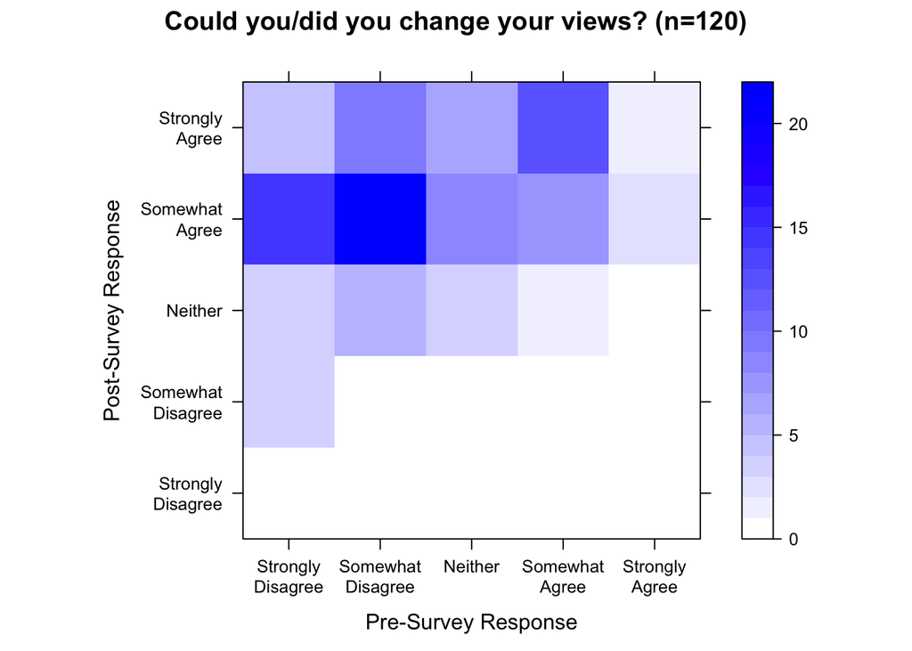

```r
library(lattice)

ccchangewide <- cctookboth %>%
  subset(CC_ChangeMind_pre != "" & CC_ChangedMe_post != "") %>%
  select(CC_ChangeMind_pre, CC_ChangedMe_post)


# Set response options
options <- c("StronglyDisagree", "SomewhatDisagree","Neither","SomewhatAgree","StronglyAgree")
n_options <- length(options)

# Create new dataframe to plot CC_Happening data as heatmap
df_cc_change <- matrix(nrow=n_options, ncol=n_options)
for (i in 1:nrow(df_cc_change)) {
  for (j in 1:ncol(df_cc_change)) {
    df_cc_change[i,j] <- sum(ccchangewide$CC_ChangeMind_pre == options[i] & ccchangewide$CC_ChangedMe_post == options[j])
  }
}

# Plot heatmap for CC_Happening Question
xylabels <- c("Strongly\nDisagree", "Somewhat\nDisagree","Neither","Somewhat\nAgree","Strongly\nAgree")

changeheatmapplot <- levelplot(df_cc_change, at=seq(0,max(df_cc_change),1),
          col.regions=colorRampPalette(c("white","blue")),
          xlab="Pre-Survey Response", ylab="Post-Survey Response",
          scales=(list(labels=xylabels, at = seq(1,5,1))),
          main = "Could you/did you change your views? (n=120)"
          )

changeheatmapplot
```

## How much had you thought about climate change before this course?

```r
CCThoughtPrecombined <- cctookbothcombined$CC_Thought_pre
CCThoughtPrecombined <- as.data.frame(CCThoughtPrecombined)
names(CCThoughtPrecombined)[1] = c("Answer")

CCThoughtPostcombined <- cctookbothcombined$CC_Thought_post
CCThoughtPostcombined <- as.data.frame(CCThoughtPostcombined)
names(CCThoughtPostcombined)[1] = c("Answer")

CCThoughtPrecombined$prepost <- rep("pre",nrow(CCThoughtPrecombined))
CCThoughtPostcombined$prepost <- rep("post",nrow(CCThoughtPostcombined))

CCThoughtDataBindcombined <- bind_rows(CCThoughtPrecombined,CCThoughtPostcombined)

CCThoughtDataBindcombined$Answer <- factor(CCThoughtDataBindcombined$Answer,
                                            c("ALot",
                                              "Some",
                                              "Little",
                                              "NotAtAll"))

CCThoughtDataBindcombined$prepost <- factor(CCThoughtDataBindcombined$prepost,
                                            c("pre",
                                              "post"))

CCthoughtsummarycombined <- CCThoughtDataBindcombined %>%
  filter(Answer != "") %>%
  group_by(prepost,Answer) %>%
  summarise(n=n()) %>%
  mutate(rel.freq = round(100 * n/sum(n), 0))

CCthoughtsummarycombined
```

```
## # A tibble: 8 x 4
## # Groups:   prepost [2]
##   prepost Answer       n rel.freq
##   <fct>   <fct>    <int>    <dbl>
## 1 pre     ALot       107       29
## 2 pre     Some       157       42
## 3 pre     Little      95       26
## 4 pre     NotAtAll    13        3
## 5 post    ALot       103       27
## 6 post    Some       151       40
## 7 post    Little     121       32
## 8 post    NotAtAll     7        2
```

```r
ntoplot <- CCThoughtDataBindcombined %>%
  filter(Answer != "") %>%
  group_by(prepost) %>%
  summarise(n=n())

ntoplot
```

```
## # A tibble: 2 x 2
##   prepost     n
##   <fct>   <int>
## 1 pre       372
## 2 post      382
```

```r
alot <- prop.test(x = c(107, 103), n = c(372, 382))
alot
```

```
##
##  2-sample test for equality of proportions with continuity
##  correction
##
## data:  c(107, 103) out of c(372, 382)
## X-squared = 0.22093, df = 1, p-value = 0.6383
## alternative hypothesis: two.sided
## 95 percent confidence interval:
##  -0.04865431  0.08465611
## sample estimates:
##    prop 1    prop 2
## 0.2876344 0.2696335
```

```r
little <- prop.test(x = c(95, 121), n = c(372, 382))
little
```

```
##
##  2-sample test for equality of proportions with continuity
##  correction
##
## data:  c(95, 121) out of c(372, 382)
## X-squared = 3.1797, df = 1, p-value = 0.07456
## alternative hypothesis: two.sided
## 95 percent confidence interval:
##  -0.128373761  0.005618595
## sample estimates:
##    prop 1    prop 2
## 0.2553763 0.3167539
```

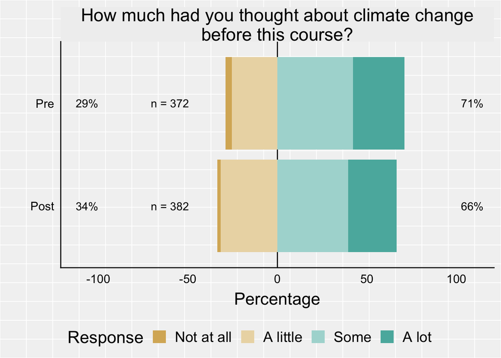

```r
CCThoughtDataBindSubsetcombined <- CCThoughtDataBindcombined %>%
  filter(Answer != "")

ccthoughtresponsescombined <- CCThoughtDataBindSubsetcombined %>%
  select(Answer)

CCThoughtDataBindSubsetcombined$prepost <- plyr::mapvalues(CCThoughtDataBindSubsetcombined$prepost , from = c("pre", "post"), to = c("Pre","Post"))

CCThoughtDataBindSubsetcombined$prepost <- factor(CCThoughtDataBindSubsetcombined$prepost, c("Post","Pre"))

# rename and order the responses

ccthoughtresponsescombined$Answer <- plyr::mapvalues(ccthoughtresponsescombined$Answer, from = c("ALot",
                                              "Some",
                                              "Little",
                                              "NotAtAll"),
                                   to = c("A lot",
                                              "Some",
                                              "A little",
                                              "Not at all"))

ccthoughtresponsescombined$Answer <- factor(ccthoughtresponsescombined$Answer,
                                 c("Not at all",
                                   "A little",
                                    "Some",
                                    "A lot"))

ccthoughtresponsescombined_grouping <- CCThoughtDataBindSubsetcombined %>%
  select(prepost)

counts = CCThoughtDataBindSubsetcombined %>%
  count(prepost) %>%
  mutate(variable=NA)

colnames(ccthoughtresponsescombined)[1] <- "How much had you thought about climate change before this course?"
likert_ccthoughtcombined <- likert(ccthoughtresponsescombined, grouping = ccthoughtresponsescombined_grouping$prepost)


ccthoughtlikertplotcombined = plot(likert_ccthoughtcombined,legend.position="bottom",text.size=4) +
  scale_y_continuous(limits=c(-100,150)) +
  coord_flip(ylim=c(-110,110)) +
  theme(text = element_text(size=17), strip.text.x = element_text(size = 18)) +
  annotate("text",x=1,y=-60,label="n = 382",size=4) +
  annotate("text",x=2,y=-60,label="n = 372",size=4)
ccthoughtlikertplotcombined <- ggplot_gtable(ggplot_build(ccthoughtlikertplotcombined))
ccthoughtlikertplotcombined$layout$clip <- "off"
ccthoughtlikertplotcombined.mpg <- plot(ccthoughtlikertplotcombined)
```

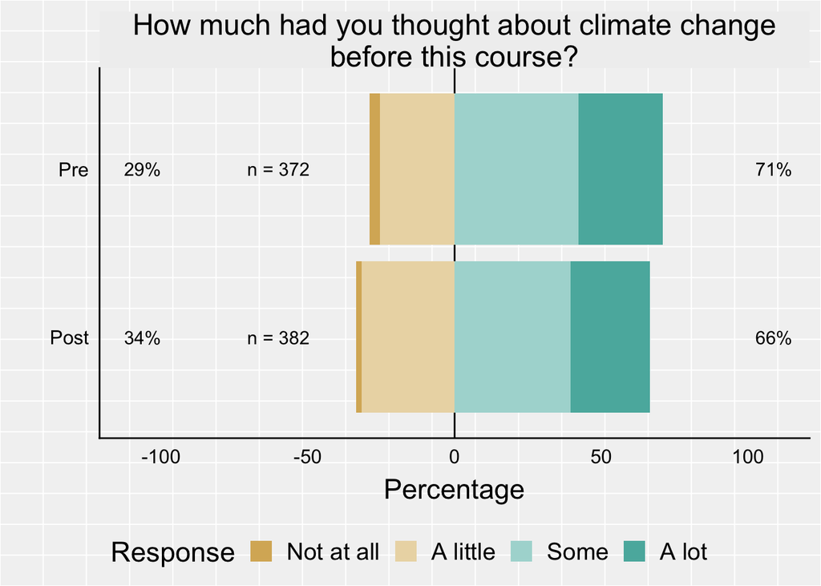

```r
plot(ccthoughtlikertplotcombined)
```

```r
save_plot("ccthoughtlikertplotcombined.jpg", ccthoughtlikertplotcombined, base_width = 8, base_height = 5)
```

## How worried are students about climate change?

```r
CCWorriedPrecombined <- cctookbothcombined$CC_Worried_pre
CCWorriedPrecombined <- as.data.frame(CCWorriedPrecombined)
names(CCWorriedPrecombined)[1] = c("Answer")

CCWorriedPostcombined <- cctookbothcombined$CC_Worried_post
CCWorriedPostcombined <- as.data.frame(CCWorriedPostcombined)
names(CCWorriedPostcombined)[1] = c("Answer")

CCWorriedPrecombined$prepost <- rep("pre",nrow(CCWorriedPrecombined))
CCWorriedPostcombined$prepost <- rep("post",nrow(CCWorriedPostcombined))

CCWorriedDataBindcombined <- bind_rows(CCWorriedPrecombined,CCWorriedPostcombined)

CCWorriedDataBindcombined$Answer <- factor(CCWorriedDataBindcombined$Answer,
                                            c("Very",
                                              "Somewhat",
                                              "Neither",
                                              "NotVery",
                                              "NotAtAll"))

CCWorriedDataBindcombined$prepost <- factor(CCWorriedDataBindcombined$prepost,
                                            c("pre",
                                              "post"))

CCworriedsummarycombined <- CCWorriedDataBindcombined %>%
  filter(Answer != "") %>%
  group_by(prepost,Answer) %>%
  summarise(n=n()) %>%
  mutate(rel.freq = round(100 * n/sum(n), 0))

CCworriedsummarycombined
```

```
## # A tibble: 10 x 4
## # Groups:   prepost [2]
##    prepost Answer       n rel.freq
##    <fct>   <fct>    <int>    <dbl>
##  1 pre     Very       160       43
##  2 pre     Somewhat   169       45
##  3 pre     Neither     29        8
##  4 pre     NotVery     13        3
##  5 pre     NotAtAll     4        1
##  6 post    Very       221       58
##  7 post    Somewhat   133       35
##  8 post    Neither     15        4
##  9 post    NotVery      9        2
## 10 post    NotAtAll     1        0
```

```r
ntoplot <- CCWorriedDataBindcombined %>%
  filter(Answer != "") %>%
  group_by(prepost) %>%
  summarise(n=n())

ntoplot
```

```
## # A tibble: 2 x 2
##   prepost     n
##   <fct>   <int>
## 1 pre       375
## 2 post      379
```

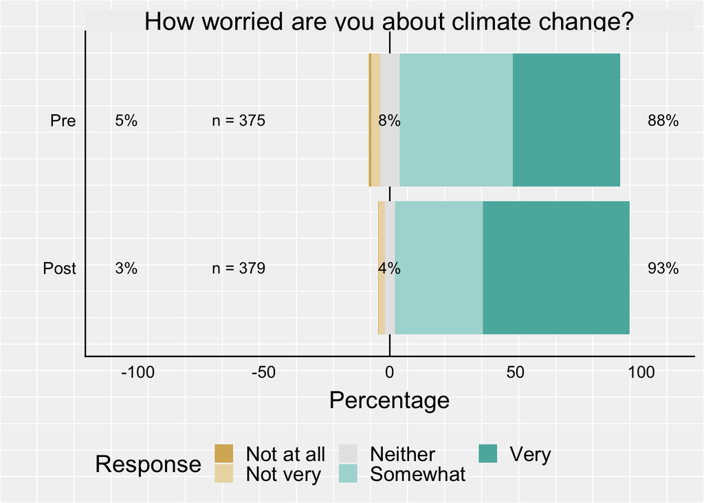

```r
CCWorriedDataBindSubsetcombined <- CCWorriedDataBindcombined %>%
  filter(Answer != "")

ccworriedresponsescombined <- CCWorriedDataBindSubsetcombined %>%
  select(Answer)

CCWorriedDataBindSubsetcombined$prepost <- plyr::mapvalues(CCWorriedDataBindSubsetcombined$prepost , from = c("pre", "post"), to = c("Pre","Post"))

CCWorriedDataBindSubsetcombined$prepost <- factor(CCWorriedDataBindSubsetcombined$prepost, c("Post","Pre"))

# rename and order the responses

ccworriedresponsescombined$Answer <- plyr::mapvalues(ccworriedresponsescombined$Answer, from = c("NotAtAll",
                                   "NotVery",
                                    "Neither",
                                    "Somewhat",
                                    "Very"),
                                   to = c("Not at all",
                                   "Not very",
                                    "Neither",
                                    "Somewhat",
                                    "Very"))

ccworriedresponsescombined$Answer <- factor(ccworriedresponsescombined$Answer,
                                 c("Not at all",
                                   "Not very",
                                    "Neither",
                                    "Somewhat",
                                    "Very"))

ccworriedresponsescombined_grouping <- CCWorriedDataBindSubsetcombined %>%
  select(prepost)

counts = CCWorriedDataBindSubsetcombined %>%
  count(prepost) %>%
  mutate(variable=NA)

colnames(ccworriedresponsescombined)[1] <- "How worried are you about climate change?"
likert_ccworriedcombined <- likert(ccworriedresponsescombined, grouping = ccworriedresponsescombined_grouping$prepost)


ccworriedlikertplotcombined = plot(likert_ccworriedcombined,legend.position="bottom",text.size=4) +
  scale_y_continuous(limits=c(-100,150)) +
  coord_flip(ylim=c(-110,110)) +
  theme(text = element_text(size=17), strip.text.x = element_text(size = 18)) +
  annotate("text",x=1,y=-60,label="n = 379",size=4) +
  annotate("text",x=2,y=-60,label="n = 375",size=4) +
  guides(fill = guide_legend(nrow=2))
ccworriedlikertplotcombined <- ggplot_gtable(ggplot_build(ccworriedlikertplotcombined))
ccworriedlikertplotcombined$layout$clip <- "off"
ccworriedlikertplotcombined.mpg <- plot(ccworriedlikertplotcombined)
```

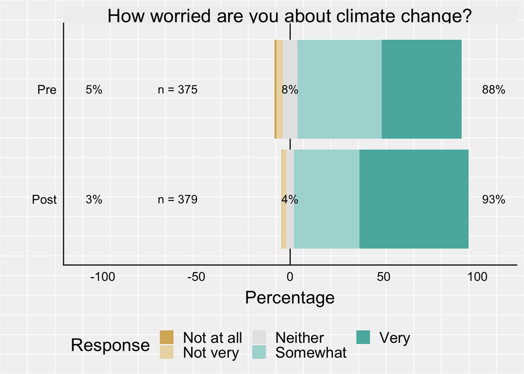

```r
plot(ccworriedlikertplotcombined)
```

```r
save_plot("ccworriedlikertplotcombined.jpg", ccworriedlikertplotcombined, base_width = 8, base_height = 5)

CCWorriedDataBindSubsetcombinedsummary <- CCWorriedDataBindSubsetcombined %>%
  group_by(prepost, Answer) %>%
  summarise(n=n()) %>%
  mutate(rel.freq = round(100 * n/sum(n), 0))

CCWorriedDataBindSubsetcombinedsummary
```

```
## # A tibble: 10 x 4
## # Groups:   prepost [2]
##    prepost Answer       n rel.freq
##    <fct>   <fct>    <int>    <dbl>
##  1 Post    Very       221       58
##  2 Post    Somewhat   133       35
##  3 Post    Neither     15        4
##  4 Post    NotVery      9        2
##  5 Post    NotAtAll     1        0
##  6 Pre     Very       160       43
##  7 Pre     Somewhat   169       45
##  8 Pre     Neither     29        8
##  9 Pre     NotVery     13        3
## 10 Pre     NotAtAll     4        1
```

```r
veryworried <- prop.test(x = c(160, 221), n = c(375, 379))
veryworried
```

```
##
##  2-sample test for equality of proportions with continuity
##  correction
##
## data:  c(160, 221) out of c(375, 379)
## X-squared = 17.836, df = 1, p-value = 2.408e-05
## alternative hypothesis: two.sided
## 95 percent confidence interval:
##  -0.22959627 -0.08329731
## sample estimates:
##    prop 1    prop 2
## 0.4266667 0.5831135
```

## How important is the issue of climate change to you personally?

```r
CCImportantPre <- cctookboth$CC_Important_pre
CCImportantPre <- as.data.frame(CCImportantPre)
names(CCImportantPre)[1] = c("Answer")

CCImportantPost <- cctookboth$CC_Important_post
CCImportantPost <- as.data.frame(CCImportantPost)
names(CCImportantPost)[1] = c("Answer")

CCImportantPre$prepost <- rep("pre",nrow(CCImportantPre))
CCImportantPost$prepost <- rep("post",nrow(CCImportantPost))

CCImportantDataBind <- bind_rows(CCImportantPre,CCImportantPost)

CCImportantDataBind$Answer <- factor(CCImportantDataBind$Answer,
                                            c("Extremely",
                                              "Very",
                                              "Neither",
                                              "MostlyNot",
                                              "NotAtAll"))

CCImportantDataBind$prepost <- factor(CCImportantDataBind$prepost,
                                            c("pre",
                                              "post"))
```

```r
CCImportantDataBindSubset <- CCImportantDataBind %>%
  filter(Answer != "")

ccimportantresponses <- CCImportantDataBindSubset %>%
  select(Answer)

CCimportantsummary <- CCImportantDataBindSubset %>%
  group_by(prepost, Answer) %>%
  summarise(n=n()) %>%
  mutate(rel.freq = round(100 * n/sum(n), 0))

CCimportantsummary
```

```
## # A tibble: 10 x 4
## # Groups:   prepost [2]
##    prepost Answer        n rel.freq
##    <fct>   <fct>     <int>    <dbl>
##  1 pre     Extremely    17       14
##  2 pre     Very         55       46
##  3 pre     Neither      38       32
##  4 pre     MostlyNot     8        7
##  5 pre     NotAtAll      2        2
##  6 post    Extremely    28       24
##  7 post    Very         67       56
##  8 post    Neither      18       15
##  9 post    MostlyNot     4        3
## 10 post    NotAtAll      2        2
```

```r
ntoplot <- CCImportantDataBindSubset %>%
  group_by(prepost) %>%
  summarise(n=n())

ntoplot
```

```
## # A tibble: 2 x 2
##   prepost     n
##   <fct>   <int>
## 1 pre       120
## 2 post      119
```

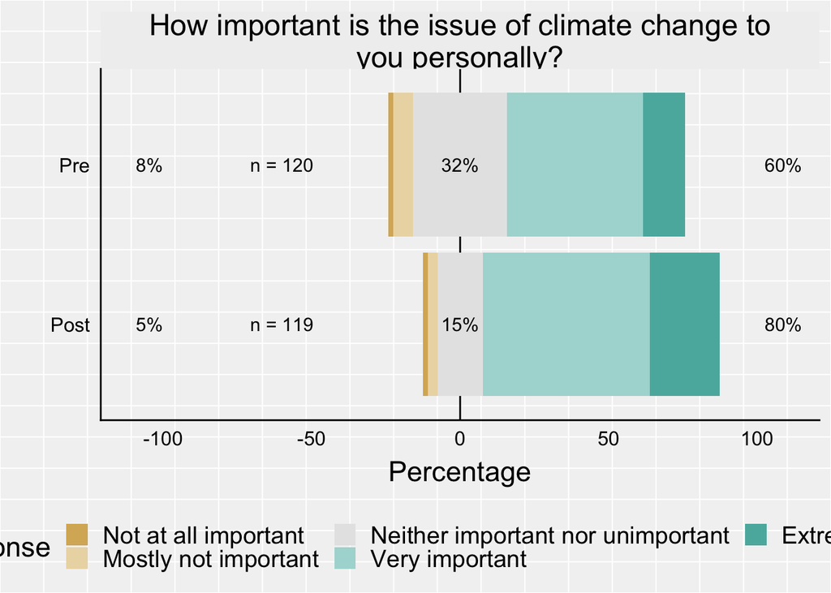

```r
CCImportantDataBindSubset$prepost <- plyr::mapvalues(CCImportantDataBindSubset$prepost , from = c("pre", "post"), to = c("Pre","Post"))

CCImportantDataBindSubset$prepost <- factor(CCImportantDataBindSubset$prepost, c("Post","Pre"))

# rename and order the responses

ccimportantresponses$Answer <- plyr::mapvalues(ccimportantresponses$Answer, from = c("Extremely",
                                              "Very",
                                              "Neither",
                                              "MostlyNot",
                                              "NotAtAll"),
                                   to = c("Extremely important",
                                              "Very important",
                                              "Neither important nor unimportant",
                                              "Mostly not important",
                                              "Not at all important"))

ccimportantresponses$Answer <- factor(ccimportantresponses$Answer,
                                 c("Not at all important",
                                   "Mostly not important",
                                    "Neither important nor unimportant",
                                    "Very important",
                                    "Extremely important"))

ccimportantresponses_grouping <- CCImportantDataBindSubset %>%
  select(prepost)

counts = CCImportantDataBindSubset %>%
  count(prepost) %>%
  mutate(variable=NA)

colnames(ccimportantresponses)[1] <- "How important is the issue of climate change to you personally?"
likert_ccimportant <- likert(ccimportantresponses, grouping = ccimportantresponses_grouping$prepost)


ccimportantlikertplot = plot(likert_ccimportant,legend.position="bottom",text.size=4) +
  scale_y_continuous(limits=c(-100,150)) +
  coord_flip(ylim=c(-110,110)) +
  theme(text = element_text(size=17), strip.text.x = element_text(size = 18)) +
  annotate("text",x=1,y=-60,label="n = 119",size=4) +
  annotate("text",x=2,y=-60,label="n = 120",size=4) +
  guides(fill = guide_legend(nrow=2))
ccimportantlikertplot <- ggplot_gtable(ggplot_build(ccimportantlikertplot))
ccimportantlikertplot$layout$clip <- "off"
ccimportantlikertplot.mpg <- plot(ccimportantlikertplot)
```

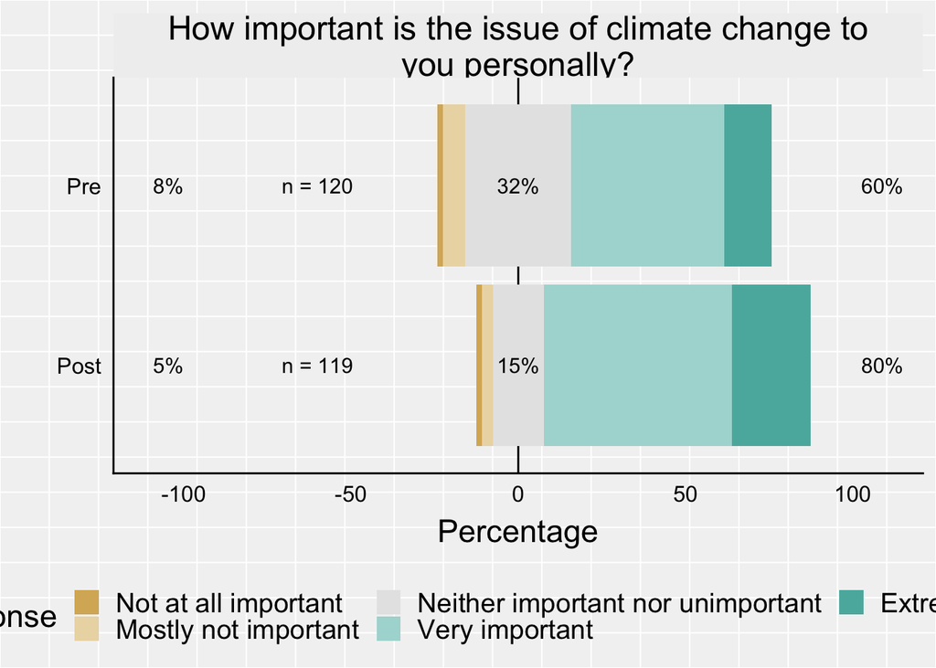

```r
plot(ccimportantlikertplot)
```

```r
save_plot("ccimportantlikertplot.jpg", ccimportantlikertplot, base_width = 8, base_height = 5)
```

```r
important <- prop.test(x = c(72, 95), n = c(120, 119))
important
```

```
##
##  2-sample test for equality of proportions with continuity
##  correction
##
## data:  c(72, 95) out of c(120, 119)
## X-squared = 10.241, df = 1, p-value = 0.001373
## alternative hypothesis: two.sided
## 95 percent confidence interval:
##  -0.32017937 -0.07645928
## sample estimates:
##    prop 1    prop 2
## 0.6000000 0.7983193
```

### Combined plot for worried & important data

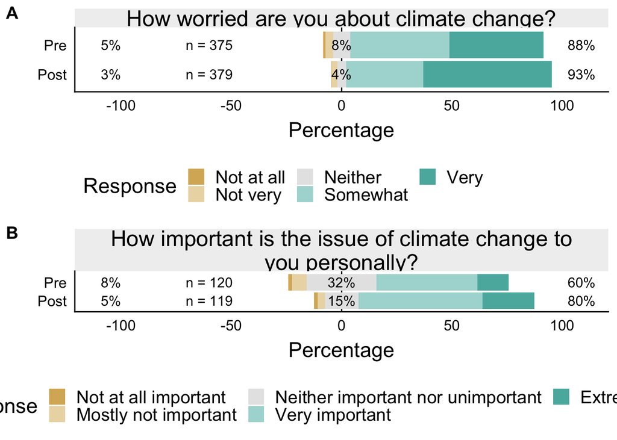

```r
combinedworryimportantplot <- plot_grid(ccworriedlikertplotcombined, ccimportantlikertplot, labels=c('A', 'B'), nrow=2, ncol=1)
combinedworryimportantplot
```

```r
save_plot("combinedworryimportantplot.jpg", combinedworryimportantplot, base_width =9.5, base_height = 8)
```

## Which of the following statements comes closest to your view?

Answer options: o Climate change isn’t happening. o Climate change is happening, but humans can’t reduce climate change. o Climate change is happening. Humans can reduce climate change, but people aren’t willing to change their behavior so we’re not going to. o Climate change is happening. Humans could reduce climate change, but it’s unclear at this point whether we will do what’s needed. o Climate change is happening. Humans can reduce climate change, and we are going to do so successfully. o Climate change is happening. Humans don’t need to try to reduce climate change, because climate change is primarily controlled by natural processes.

The codes for those in the data are: -NotHappening -CantReduce -Unwilling -Unclear -Success -DontNeed

Note: I was initially confused about what was going on with the “can’t reduce” option, since it appeared as a level in R but wasn’t appearing on the figure. Looking into it more, some students chose that option, but the only students who chose it were students who answered the validation question incorrectly at the beginning and/or end of the semester. So, it doesn’t appear on the figure because those students are filtered out.

```r
CCViewPre <- cctookboth$CC_View_pre
CCViewPre <- as.data.frame(CCViewPre)
names(CCViewPre)[1] = c("Answer")

CCViewPost <- cctookboth$CC_View_post
CCViewPost <- as.data.frame(CCViewPost)
names(CCViewPost)[1] = c("Answer")

CCViewPre$prepost <- rep("pre",nrow(CCViewPre))
CCViewPost$prepost <- rep("post",nrow(CCViewPost))

CCViewDataBind <- bind_rows(CCViewPre,CCViewPost)

CCViewDataBind$Answer <- factor(CCViewDataBind$Answer,
                                            c("DontNeed",
                                              "Success",
                                              "Unclear",
                                              "Unwilling",
                                              "CantReduce",
                                              "NotHappening"))

CCViewDataBind$prepost <- factor(CCViewDataBind$prepost,
                                            c("pre",
                                              "post"))
```

```r
CCViewPercents <-
  CCViewDataBind %>%
  filter(Answer != "") %>%
  group_by(prepost,Answer) %>%
  summarise(n=n()) %>%
  mutate(rel.freq = round(100 * n/sum(n), 0))

extradata <- data.frame(prepost = c("pre","post"), Answer = c("CantReduce","CantReduce"), n = c(0, 0),rel.freq=c(0, 0))

CCViewPercents <- bind_rows(CCViewPercents,extradata)
CCViewPercents
```

```
## # A tibble: 12 x 4
## # Groups:   prepost [2]
##    prepost Answer           n rel.freq
##    <fct>   <chr>        <dbl>    <dbl>
##  1 pre     DontNeed         1        1
##  2 pre     Success          3        2
##  3 pre     Unclear         70       58
##  4 pre     Unwilling       44       37
##  5 pre     NotHappening     2        2
##  6 post    DontNeed         1        1
##  7 post    Success          5        4
##  8 post    Unclear         77       64
##  9 post    Unwilling       35       29
## 10 post    NotHappening     2        2
## 11 pre     CantReduce       0        0
## 12 post    CantReduce       0        0
```

```r
ntoplot <- CCViewDataBind %>%
  filter(Answer != "") %>%
  group_by(prepost) %>%
  summarise(n=n())

ntoplot
```

```
## # A tibble: 2 x 2
##   prepost     n
##   <fct>   <int>
## 1 pre       120
## 2 post      120
```

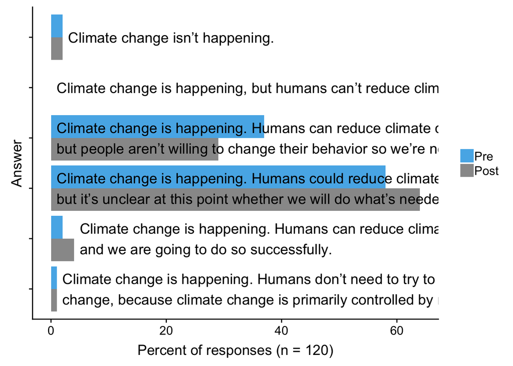

```r
CCViewPercents$prepost <- plyr::mapvalues(CCViewPercents$prepost , from = c("pre", "post"), to = c("Pre","Post"))

CCViewPercents$prepost <- factor(CCViewPercents$prepost, c("Post","Pre"))

CCViewPercents$Answer <- factor(CCViewPercents$Answer,
                                            c("DontNeed",
                                              "Success",
                                              "Unclear",
                                              "Unwilling",
                                              "CantReduce",
                                              "NotHappening"))

CCViewFlippedPlot <- ggplot(CCViewPercents,aes(x=Answer,y=rel.freq,fill= prepost)) +
  geom_bar(stat="identity",position=position_dodge()) +
  ylab("Percent of responses (n = 120)") +
  coord_flip() +
  theme(axis.text.y = element_blank()) +
  annotate("text", x = 1, y = 2, label = "Climate change is happening. Humans don’t need to try to reduce climate\nchange, because climate change is primarily controlled by natural processes.",hjust=0,size=5) +
  annotate("text", x = 2, y = 5, label = "Climate change is happening. Humans can reduce climate change,\nand we are going to do so successfully.",hjust=0,size=5) +
  annotate("text", x = 3, y = 1, label = "Climate change is happening. Humans could reduce climate change,\nbut it’s unclear at this point whether we will do what’s needed.",hjust=0,size=5) +
  annotate("text", x = 4, y = 1, label = "Climate change is happening. Humans can reduce climate change,\nbut people aren’t willing to change their behavior so we’re not going to.",hjust=0,size=5) +
  annotate("text", x = 5, y = 1, color="black", label = "Climate change is happening, but humans can’t reduce climate change.",hjust=0,size=5) +
  annotate("text", x = 6, y = 3, color="black", label = "Climate change isn’t happening.",hjust=0,size=5) +
  scale_fill_manual(values=c("#999999", "#56B4E9")) +
  guides(fill = guide_legend(reverse=TRUE)) +
  theme(legend.title=element_blank(),panel.grid.major = element_blank(), panel.grid.minor = element_blank(),
panel.background = element_blank(), axis.line = element_line(colour = "black"))

CCViewFlippedPlot
```

```r
save_plot("CCViewFlippedPlot2.jpg", CCViewFlippedPlot, base_width = 8.5, base_height = 6)
```

## Do their friends share their views on climate change?

CC_Friends How many of your friends share your views on climate change? o None o A few o Some o Most o All o I don’t know

```r
CCFriendsPre <- cctookboth$CC_Friends_pre
CCFriendsPre <- as.data.frame(CCFriendsPre)
names(CCFriendsPre)[1] = c("Answer")

CCFriendsPost <- cctookboth$CC_Friends_post
CCFriendsPost <- as.data.frame(CCFriendsPost)
names(CCFriendsPost)[1] = c("Answer")

CCFriendsPre$prepost <- rep("pre",nrow(CCFriendsPre))
CCFriendsPost$prepost <- rep("post",nrow(CCFriendsPost))

CCFriendsDataBind <- bind_rows(CCFriendsPre,CCFriendsPost)

CCFriendsDataBind$Answer <- factor(CCFriendsDataBind$Answer,
                                            c("All",
                                              "Most",
                                              "Some",
                                              "Few",
                                              "None",
                                              "DK"))

CCFriendsDataBind$prepost <- factor(CCFriendsDataBind$prepost,
                                            c("pre",
                                              "post"))
```

```r
CCFriendsDataBindAll <- CCFriendsDataBind

CCFriendsDataBindAll$prepost <- plyr::mapvalues(CCFriendsDataBindAll$prepost , from = c("pre", "post"), to = c("Pre","Post"))

CCfriendssummaryall <- CCFriendsDataBindAll %>%
  filter(Answer != "") %>%
  group_by(prepost,Answer) %>%
  summarise(n=n()) %>%
  mutate(rel.freq = round(100 * n/sum(n), 0))

CCfriendssummaryall
```

```
## # A tibble: 12 x 4
## # Groups:   prepost [2]
##    prepost Answer     n rel.freq
##    <fct>   <fct>  <int>    <dbl>
##  1 Pre     All       12       10
##  2 Pre     Most      61       53
##  3 Pre     Some      21       18
##  4 Pre     Few        2        2
##  5 Pre     None       2        2
##  6 Pre     DK        17       15
##  7 Post    All       20       18
##  8 Post    Most      65       57
##  9 Post    Some       9        8
## 10 Post    Few        5        4
## 11 Post    None       1        1
## 12 Post    DK        14       12
```

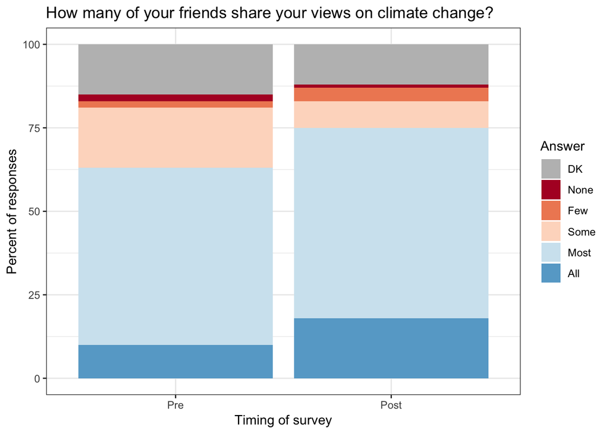

```r
# order the responses
CCfriendssummaryall$Answer <- factor(CCfriendssummaryall$Answer,
                                 c("NA",
                                   "DK",
                                   "None",
                                   "Few",
                                   "Some",
                                   "Most",
                                   "All"))


ccfriendsstackedbarplot <- ggplot(CCfriendssummaryall, aes(y=rel.freq, x=prepost)) +
    geom_col(aes(fill=Answer)) +
  ylab("Percent of responses") +
  xlab("Timing of survey") +
  scale_fill_manual(values=c("gray","#b2182b","#ef8a62","#fddbc7","#d1e5f0","#67a9cf","#2166ac")) +
  ggtitle("How many of your friends share your views on climate change?") +
  theme_bw()


ccfriendsstackedbarplot
```

```r
save_plot("ccfriendsstackedbarplot.jpg", ccfriendsstackedbarplot, base_width = 6, base_height = 5)
```